# Basic statistics

Nambeom Kim

2021 3 1

## 국가기술 빅데이터 분석기사

[데이터자격시험](https://www.dataq.or.kr/www/sub/a_07.do)

# R/Rstudio install

## Getting started R program

R program download  
- https://www.r-project.org/

R-Studio download - https://www.rstudio.com/

## R graph gallery

- https://www.r-graph-gallery.com
- https://shiny.rstudio.com/gallery

# 기초통계학

## 자료의 종류

### 연속형 자료

- 등간척도 (Interval): 절대값 0이 존재하지 않음, 곱셈법칙 적용이 안됨, 예)온도
- 비율척도 (Ratio): 절대값 0이 존재, 예) 키, 몸무게, 혈압

### 범주형 자료

- 명목척도 (Nominal): 속성을 분류하는 척도, 속성간 순위가 없음, 예) 남/녀, 국어/영어/수학
- 순서척도 (Ordinal): 속성간에 순위개념이 존재하는 척도, 예) 상/중/하, 좋음/보통/나쁨

### 확률변수의 종류표

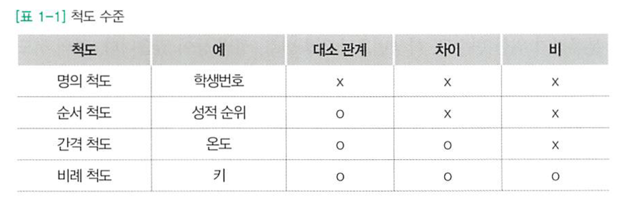

누구나 파이썬 통계분석

```r
url <- "fig/variable_type.png"
knitr::include_graphics(url)
```

## 자료의 축약

### 모집단과 표본집단

- 모집단: 이해하고자 하는 집단전체, 예)우리나라 고등학생 평균키, 고혈압환자
- 표본집단 : 모집단에서 추출된 집단, 예) 추출된 고등학생 100명, 연구에 참여한 고혈압 환자 50명

## 범주형 자료의 요약

### 돗수분포표 (Frequency table)

- 각 범주에 속하는 관측값의 갯수를 그 범주의 돗수라고 함
- 이 돗수를 전체 자료의 갯수로 나눈 값을 상대돗수라고 함
- 각 범주에 대응되는 돗수 와 상대돗수를 나타낸 표

## 연속형 자료의 요약

- 히스토그램 (Histogram)
- 상자수염 그림 (Boxplot)
- 바이올린 그림 (Violin plot)

## 그래프를 통한 자료의 요약의 장단점

- 장점: 자료를 한 눈에 알아볼 수 있음
- 단점: 그림의 모양이 작성자의 주관적 판단에 따라 달라질 수 있음

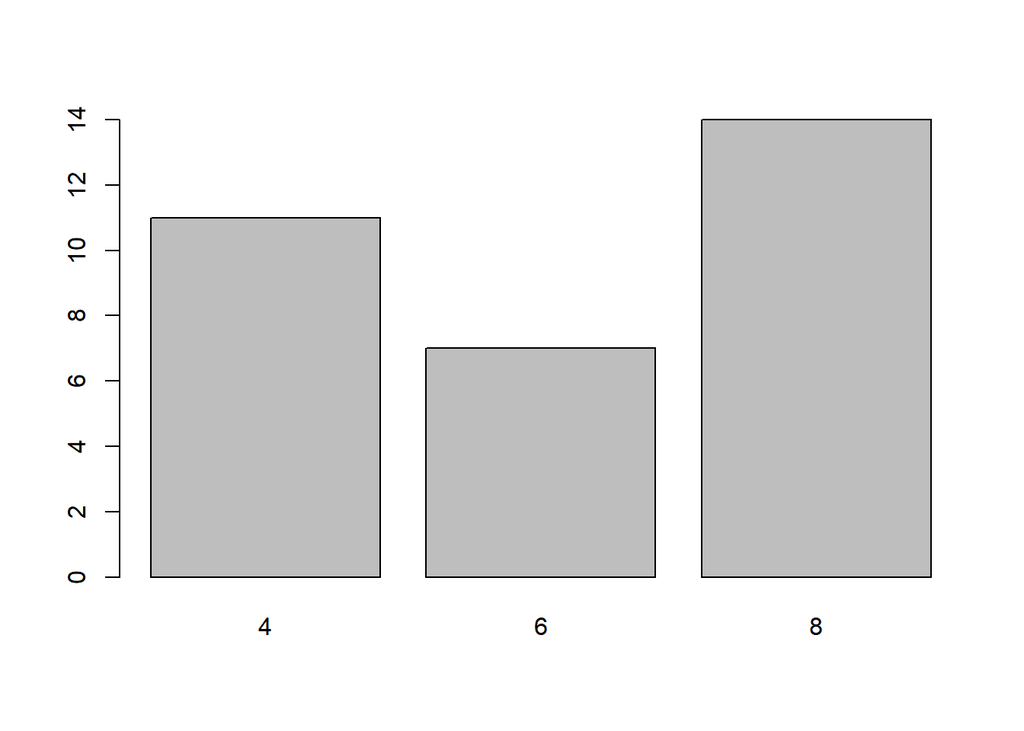

```r
# Barplot
barplot(table(mtcars$cyl))
```

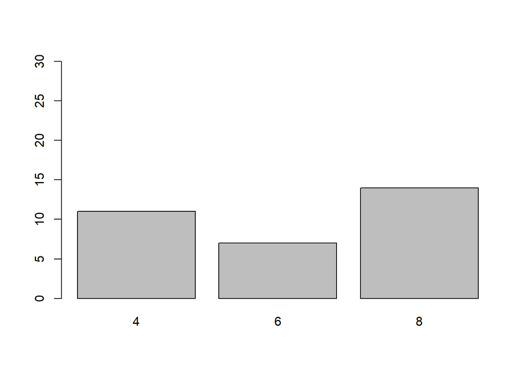

```r
barplot(table(mtcars$cyl),
        ylim = c(0, 30))
```

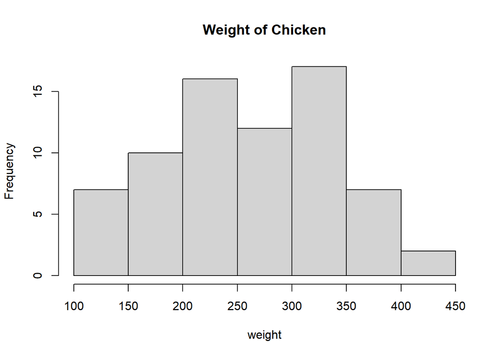

```r
# Barplot
chickwts %>%
  with(., hist(weight,
               main = "Weight of Chicken")
       )
```

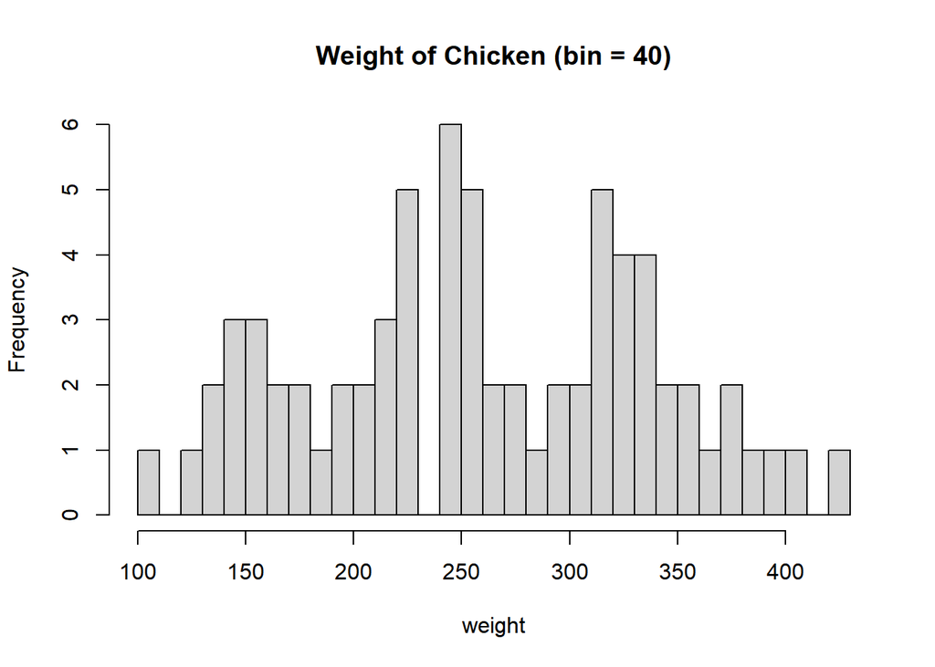

```r
chickwts %>%
  with(., hist(weight,
               main = "Weight of Chicken (bin = 40)",
               nclass = 40)
       )
```

## 수치를 통한 연속형 자료의 요약

### 중심위치의 측도

- 표본평균 (Sample Mean)
  - 중심을 나타내는 측도 중에서 가장 많이 사용되는 방법
  - 자료의 무게 중심을 나타냄
  - $\overline x = \frac{\sum_{i = 1}^{n} x_i}{n}$
  - 자료의 이상치 (Outlier)에 영향을 많이 받음 (Trimmed mean)
- 중앙값 (Median)
  - 전체 관측값을 크기 순으로 나열한 했을 때 중앙에 위치한 값
  - Median (m): $P(X \le m) = \int_{-\infty }^{m}f(x)dx = \frac{1}{2}$
  - 자료의 갯수(n) 이 홀수이면 $\frac{n+1}{2}$ 번째 관측값
  - 자료의 갯수(n) 이 짝수이면 $\frac{n}{2}$과 $\frac{n+1}{2}$ 번째 관측값의 평균값
  - 자료의 이상치 (Outlier)에 영향을 적게 받음
- 최빈값 (Mode)
  - 관측값 가운데 가장 자주 나온 값

### 예제

```r
set.seed(7201)
c <- round(runif(6, 1, 10),0)

c
```

```
[1]  5  3  5 10  9  8
```

```r
mean(c)
```

```
[1] 6.666667
```

```r
median(c)
```

```
[1] 6.5
```

```r
as_tibble(c) %>%
  count(value)
```

```
# A tibble: 5 x 2
  value     n
  <dbl> <int>
1     3     1
2     5     2
3     8     1
4     9     1
5    10     1
```

## 표본평균, 중앙값, 최빈값의 비교

- 표본평균은 이해하기 쉽고 이론적 전개가 용이
- 표본평균은 전체 관측치를 반영하지만 이상치 (Outlier)에 영향을 받음
- 중앙값 중앙 부분의 관측치에 영향을 받고 이상치 (Outlier)에 영향을 받지 않음
- 이상치 들이 있는 경우 표본평균과 중앙을 적절히 사용

### 어느 보험회사 직원 7명의 한달 수입은 다음과 같다

- 수입의 평균과 중앙값을 구하여라
- 두 개의 값 중에서 어느 것이 중심위치를 측정하기에 적당한가?

```r
(df <- c(950, 775, 925, 2500, 1150, 850, 975))
```

```
[1]  950  775  925 2500 1150  850  975
```

```r
mean(df)
```

```
[1] 1160.714
```

```r
median(df)
```

```
[1] 950
```

## 퍼짐의 정도

### 분산과 표준편차 (Variance and Standard deviation, SD)

- 자료가 중심으로 부터 얼마나 퍼져있는 지를 표현 수치
- $S^2 = \frac{\sum_i^N (X_{i}-\overline{X})^2}{N-1}$
- sd = $\sqrt{S^2} = S$
- 범위(Range): 최댓값 - 최솟값
- 사분위수범위(InterQuartile Range, IQR): 3사분위수 - 1사분위수

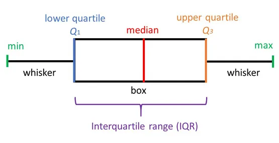

https://www.simplypsychology.org/boxplots.html

- 표본분산, 표본표준편차, 범위, 사분위수를 구하여라

```r
(df <- c(2, 3, 5, 7, 9, 10))
```

```
[1]  2  3  5  7  9 10
```

### 표본편차, 범위, 사분위수범위 비교

- 표준편차는 표본평균과 같은 이론적 배경
- 사분위수 범위는 중앙값과 같은 이론적 배경
- 중심측도로서 표본평균를 사용할 경우 표준편차를 사용
- 중심측도로서 중앙값을 사용할 경우 사분위수 범위를 사용

### 연습문제

```r
set.seed(202103)
(df <- c(round(runif(6, 10, 20), 0)))
```

```
[1] 20 18 19 18 12 14
```

## 두 변수간의 자료 요약

### 분할표

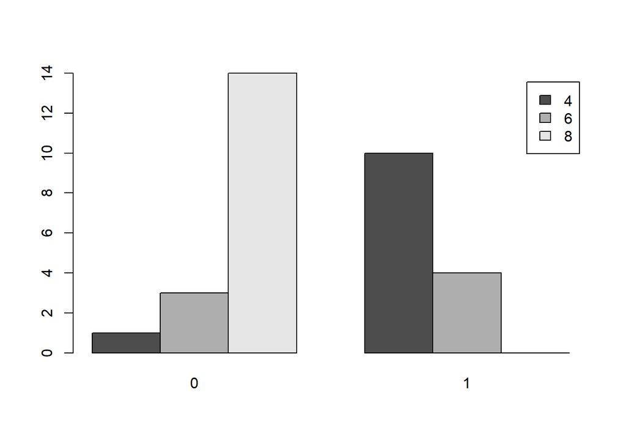

```r
mydf <- table(mtcars$cyl, mtcars$vs,
      dnn = list(c = "Cylinder",
                 r = "Transmission"))

barplot(mydf, beside = T, legend.text = T)
```

### 상관분석 (Correlation)

- 두 연속형 변수간에 선형적 연관관계가 있는 지를 분석하는 통계적 방법
- 두 연속형 변수간의 연관된 정도를 나타내는 척도이며 인과관계를 설명하는 것은 아님
- 상관계수(Correlation coefficient)는 선형적 관계의 강도를 나타냄
- 모집단 상관계수는 $\rho$, 표본집단의 상관계수는 $r$로 표기

### 피어슨 상관계수 (Pearson’s r)

- 두 연속형 변수가 정규분포를 따르는 경우에 사용함
- r 값이 + 이면 양의 상관관계, - 값이면 음의 상관 관계를 의미
- r 값의 범위는 -1 에서 +1 까지 분포하며 절대값이 1에 가까울 수록 높은 상관성을 의미
- r 값의 해석 (절대적 기준은 아님)
  - 절대값이 0.7 ~ 0.9 : 높은 상관 관계
  - 절대값이 0.4 ~ 0.7 : 중등도 상관 관계

$ r_{p} = $  
$r_{p} = \frac{Cov(x, y)}{\sqrt{Var(x)}\sqrt{Var(y)}}$  
$Cov(X, Y) = E(X-u_X)(Y-u_Y) = \frac{\sum_i^n(X_i-\overline{X})(Y_i-\overline{Y})}{n-1}$

### 그림을 통한 상관관계 요약: 산점도

### 예제) 다음 자료 간에 상관성을 구하여라

| 수학점수 | 영어점수 |
| --- | --- |
| 88 | 73 |
| 55 | 65 |
| 66 | 70 |
| 62 | 62 |
| 69 | 68 |

### 예제) 다음 자료 간에 상관성을 구하여라

```r
set.seed(7201)
(df <- data.frame(v1 = round(runif(6, 1, 10),0),
                  v2 = round(runif(6, 20, 30),0)))
```

```
  v1 v2
1  5 23
2  3 24
3  5 25
4 10 29
5  9 24
6  8 24
```

## 확률

### 예제

- 주말 오후 경부고속도로에서 143 대의 승용차에 대해서 버스전용차로제 위반을 단속했다. 표본공간과 60% 이상의 차들이 위반하게 되는 사건 A의 경우를 근원사건을 이용해서 나타내 보아라
- 표본공간과 근원사건

### 확률의 법칙

- 모든 사건 A 에 대하여 $0 \le P(A) \le 1$
- $P(A) = \sum_{\omega_i \in A} P(\omega_i)$
- $P(\Omega) = \sum_{\omega_i \in \Omega} P(\omega_i) = 1$

### 예제

- 네 개의 근원사건으로 이루어진 표본공간이 있을 때 $P(\omega_1) = 0.1, P(\omega_2) = 0.5, P(\omega_3) = 0.1$ 일 때, $P(\omega_4)$는 얼마인가?

### 확률의 계산

- 여사건의 법칙: $P(A^c) = 1-P(A)$
- 합사건의 법칙: $P(A \cup B) = P(A) + P(B) - P(A \cap B)$
- 합사건의 여사건: $P((A \cup B)^c) = P(A^c \cap B^c)$
- 조건부확률: $P(A|B) = \frac{P(A \cap B)}{P(B)},\ P(B) > 0$
- 두 사건 A,B가 독립인 경우: $P(A \cap B) = P(A)P(B)$

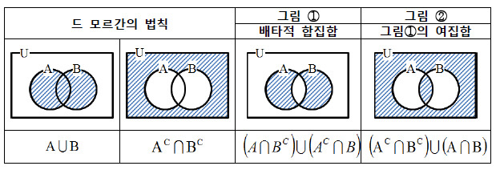

  https://exammoa.tistory.com/394

### 조건부확률 예제

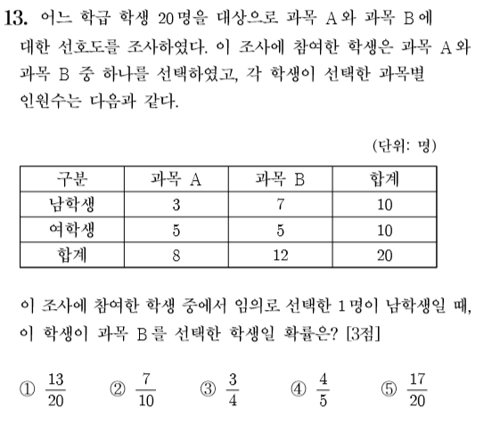

http://godingmath.com/changecb

### 독립사건 예제

- 남자일 사건을 M, 금연찬성일 사건을 A라 할 때, 사건 M과 A가 서로 독립인지 판단 하여라

```r
df
```

```
          gender
No_smoking 남자 여자
      찬성   24   14
      반대   16    6
```

## 확률분포

### 이산 (범주형) 확률변수와 확률분포

- 확률분포 (Probability distribution): 확률변수가 갖는 값들과 그에 대응하는 확률값
  - 세 명의 주부가 각 각 바지(B)와 치마(A)를 산다고 가정하자. 확률변수 X를 세 명 중 바지를 구매한 주부의 수라고 하자.
  - $\Omega$ = {AAA, ABA, AAB, BAA, BAB, ABB, BBA, BBB}
  - 확률변수 $X =$ {0, 1, 2, 3}, P(X=1) = 3/8
  - 이산확률변수 X의 확률잘량함수 $P(X)$는 다음의 조건을 만족해야 함
    - 모든 $x_i$ 값에 대해 $0 \le P(x_i) \le 1$
    - $\sum_{x_i}P(x_i) = 1$

### 이산확률변수 예제

- 어느 삼림의 30%가 병충해를 입었다고 하자. 4그루의 나무를 임의로 추출했을 때 병충해를 입고 있는 나무의 수 X의 확률분포를 구하여라

### 도수분포표로 부터 모분산 구하기

- $\overline X = \sum x_if(x_i)$
- $Var(x) = \sum (x_i- \mu)^2f(x_i) = \sum x_i^2f(x_i)-\mu^2$

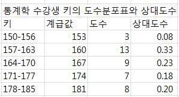

### 그림 1

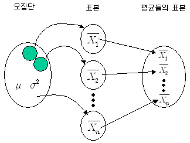

https://moderndive.com/2-getting-started.html

## 유의수준과 유의확률의 정의와 개념

### 귀무가설 (Null hypothesis, H0)과 대립가설 (Alternative hypothesis, H1)

- H0: Not H1
- H1: 연구자가 연구를 통해 입증하고자 하는 주장
  - 남성 월급이 여성 월급보다 더 많다.
  - 새로 개발된 신약은 혈압 강하에 더 효과적 이다.
  - A 회사의 평균연봉은 4000만원 보다 적다

### 가설검정의 전략

```
- 귀무가설의 채택 -> 대립가설을 기각
- 귀무가설의 기각 -> 대립가설을 채택
- 귀무가설의 기각의 기준 <=> 귀무가설이 참일 때 표본값이 얻어질 확률을 기준
```

### 유의수준 = 기각역 ($\alpha$-value) = 제1종오류(Type-1 error)

- $maxP$ (귀무가설을 기각 $\mid \theta = \theta_{0})$
- 자료 분석 전에 미리 설정
- 예) 체육시험에서 100m를 16초 안에 들어오면 합격 = $\alpha$ value = 0.05

### 유의확률 (P-value)

- $P$(실험에 의해서 얻어진 결과값(예,평균) $\mid \theta = \theta_{0})$
- 자료 분석 후에 결과치
- 예) 철수는 100m를 12초에 들어와서 합격 = 실험같은 결과값이 나올 확률이 0.05 미만이므로 귀무가설을 기각

### 이항분포 예제

- 이항분포(Binomial dist’n) 확률질량함수, $P(x) = \binom{n}{x}p^x(1-p)^{n-x}$

```
[1] "Trials = 6 , Success = from 0 to 6 , Null probability =  0.5"
```

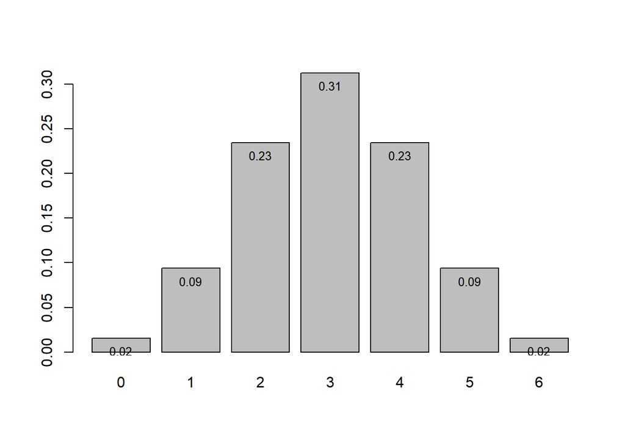

- $\alpha$ value = 0.05를 만족하는 x값은 0과 6

### 기각치와 p-value 나타낸 그림

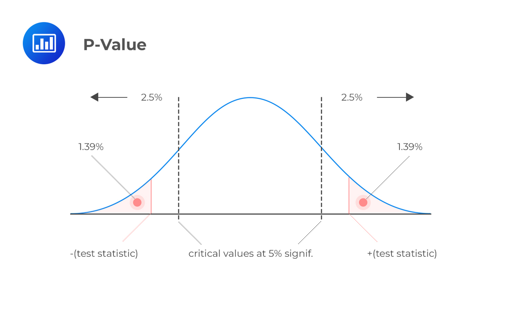

https://analystprep.com/cfa-level-1-exam/quantitative-methods

# **z-검정 (z-test)**

- 얻어진 랜덤표본으로부터 정규모집단이 특정 **평균($\mu$)** 을 가지는 지를 검증하는 통계적 방법
- 대립가설의 종류
  - $H_1: \mu \neq k_o$, $H_0: \mu = k_o$; (양측검정, Two-tailed)
  - $H_1: \mu \gt k_o$, $H_0: \mu \le k_o$; (단측검정, Upper-tailed)
  - $H_1: \mu \lt k_o$, $H_0: \mu \ge k_o$; (단측검정, Lower-tailed)

### 정규분포 (Normal distribution)의 특징

- 확률밀도함수
  $$\large P(x) = \frac{1}{{\sigma \sqrt {2\pi } }}e^{- \frac{(x - \mu)^2}{2\sigma ^2 }}$$
- $X \sim^{i.i.d} \mathcal{N}(\mu,\,\sigma^{2})$, $\mu$ = 평균, $\sigma^2$ = 분산
- 연속형 변수에 대해서 정의
- $\mu$ 를 중심으로 대칭이며 자료는 $\mu$로 부터 평균적으로 $\sigma$ 떨어져 있음
- 평균, 중위수, 최빈값이 모두 같음
- 확률밀도함수 아래의 면적이 확률을 나타냄

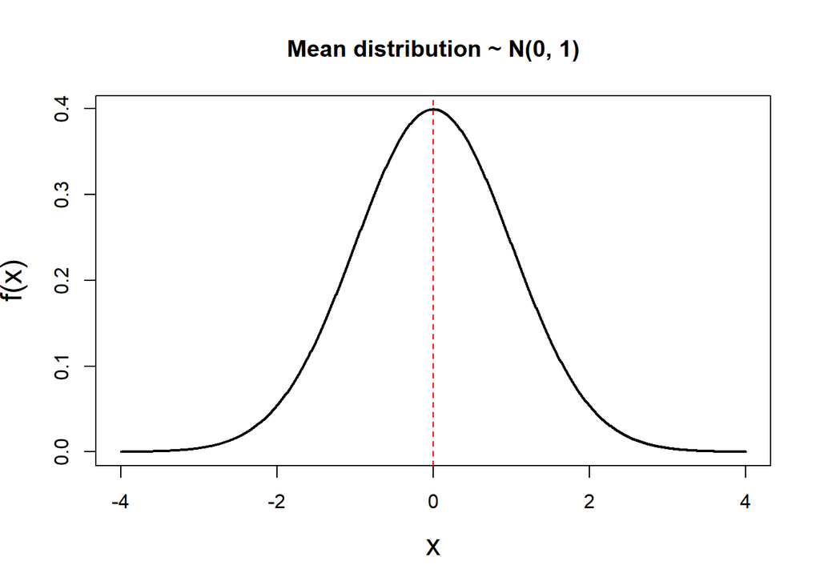

### 분위수를 이용한 확률계산, IQ score

[figure not shown]

https://www.spss-tutorials.com/normal-distribution

### 평균과 분산에 따른 정규분포의 모양

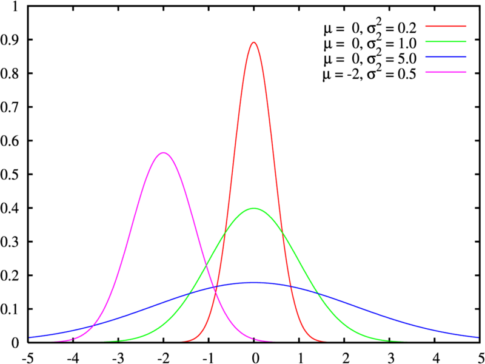

https://ko.wikipedia.org/wiki

## 정규분포에 근거한 가설검정의 절차와 유의확률

- $H_1:$ 빵집에서 판매하고 있는 빵의 평균 무게는 100g이 아니다 = $\mu \ne 100g$
- $H_0:$ Not $H_1$ = $\mu = 100g$
- 유의수준을 설정 ($\alpha$-value) = 0.05
- 유의확률을 계산
  - 표본 추출: 빵 100개로 부터 평균과 표준편차를 계산
  - 표준오차를 계산
  - 정규분포의 확률밀도 함수를 추정
  - 유의확률을 계산

### 예제 1

```r
set.seed(7201)
df <- round(rnorm(n=10, mean = 95, sd = 16))
df
```

```
 [1]  91  94 111  85  96  91 114 101  81 100
```

```r
# mean and variance, se
df_mean <- mean(df)
df_se <- 16/sqrt(10)

# calculate cdf probability
pnorm(df_mean, mean = 95, sd = df_se , lower.tail = T)
```

```
[1] 0.609
```

[figure not shown]

- 앙리 프렝카레와 빵집 간의 소송

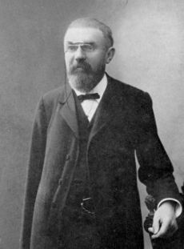

http://wikimedia.org

### 예제 2

- 모분산이 1인 정규모집단으로 부터 얻어진 음료수 샘플이 아래와 같다
- 음료수의 양(ml) = c(99, 97, 102, 88, 103, 91)
- 대립가설 $H_1: \mu \lt 100ml$ 이 옮은지 유의수준 0.05에서 검정하여라

## 정규분포의 표준화

### 정규분포 표준화의 필요성

- 평균과 분산이 다를 경우 확률을 구하기 위해서는 복잡한 정규본포 확률밀도 함수를 적분해야 함
- 정규화를 통해서 확률을 쉽게 구할 수 있음
- 확률밀도함수의 적분
  $$\large P(X \gt x_0) = \int_{x_0}^{\infty} \frac{1}{{\sigma \sqrt {2\pi } }}e^{- \frac{(x - \mu)^2}{2\sigma ^2 }}dx$$

### 정규분포의 표준화 방법

$$\large X \sim N(\mu, \sigma^2), Z = \frac{X- \mu}{\sigma}, Z \sim \mathcal{N}(0,\,1)$$
$$\large \overline{X} \sim N(\mu, \frac{\sigma^2}{n}), Z = \frac{\overline{X} - \mu}{ \frac{\sigma}{\sqrt n}}, Z \sim \mathcal{N}(0,\,1)$$

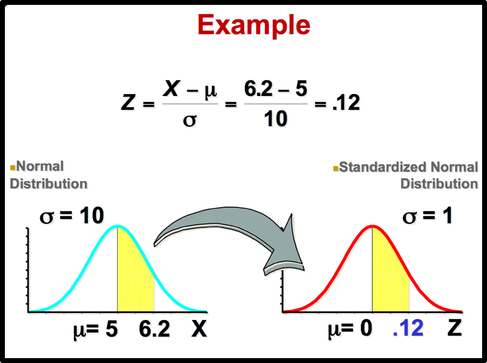

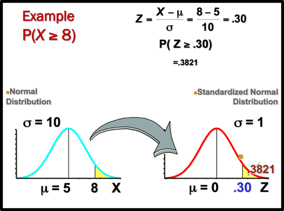

https://statisticstechs.weebly.com/desciptive-statistics/category/f-normal-distribution

### 예제 3

```r
set.seed(7201)
df <- round(rnorm(n=10, mean = 95, sd = 16))
df
```

```
 [1]  91  94 111  85  96  91 114 101  81 100
```

```r
# mean and variance, se
df_mean <- mean(df)
df_se <- 16/sqrt(10)
z_value <- (df_mean-95)/df_se
# calculate cdf probability
pnorm(z_value, mean = 0, sd = 1 , lower.tail = T)
```

```
[1] 0.609
```

### 표준정규분포의 특징

- 표준정규분포 확률밀도함수
  $$\large P(x) = \frac{1}{{\sqrt {2\pi} }}e^{-\frac{x^2}{2}}$$
- 평균이 0 이고 분산이 1
- z 분위수 -1.96과 1.96 사이에 자료의 95%가 존재 (95% 신뢰구간)

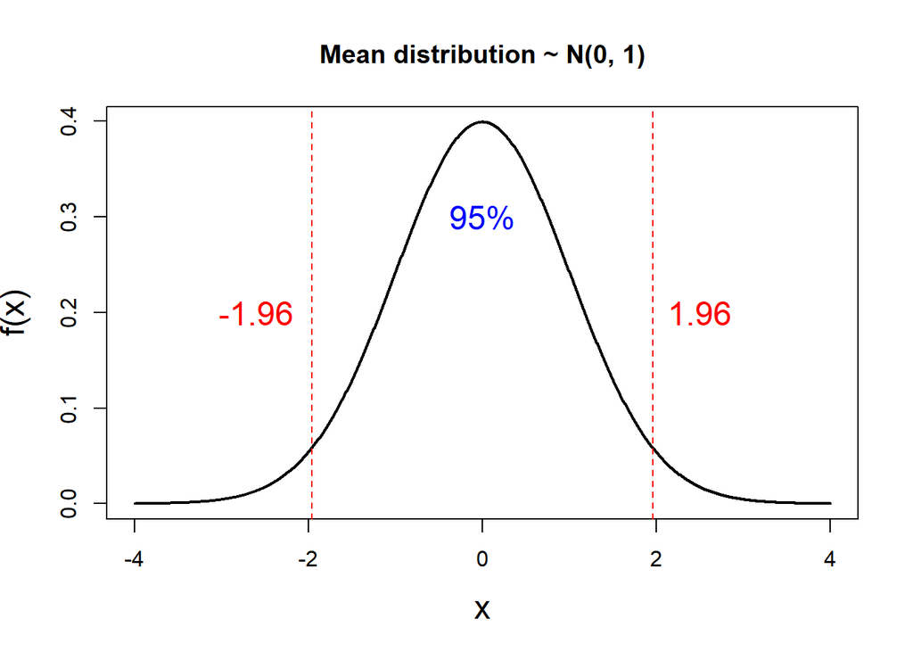

### 표준정규분포에서 모평균의 신뢰구간

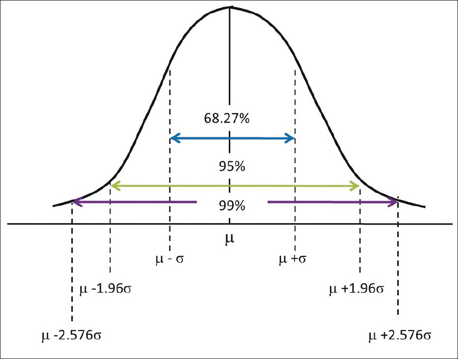

http://www.jcd.org.in

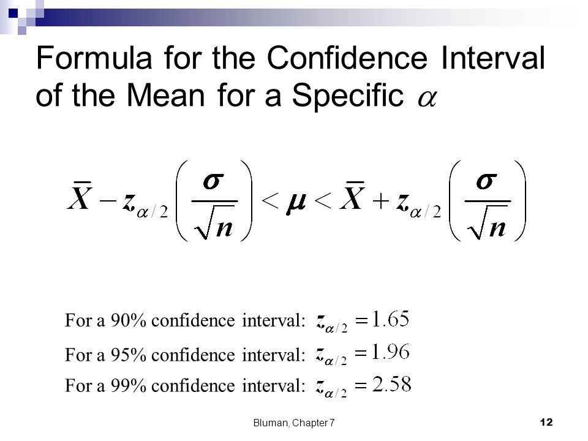

https://slideplayer.com/slide/7268813

# **Student’s t-검정**

## **독립 일표본 T 검정 (One-sample T-test)**

## 정규분포와 Student’s T-분포와의 관계

- 모집단의 분산을 모르는 경우
- 자료의 수가 많지 않은 경우 (예, n = 30 미만)

$$\large \overline{X} \sim N(\mu, \frac{\sigma^2}{n})$$
$$\large \frac{\overline{X}- \mu}{ \frac{\sigma}{\sqrt n}} \sim Z$$
$$\large \frac{\overline{X}- \mu}{ \frac{S}{\sqrt n}} \sim t(n-1)$$

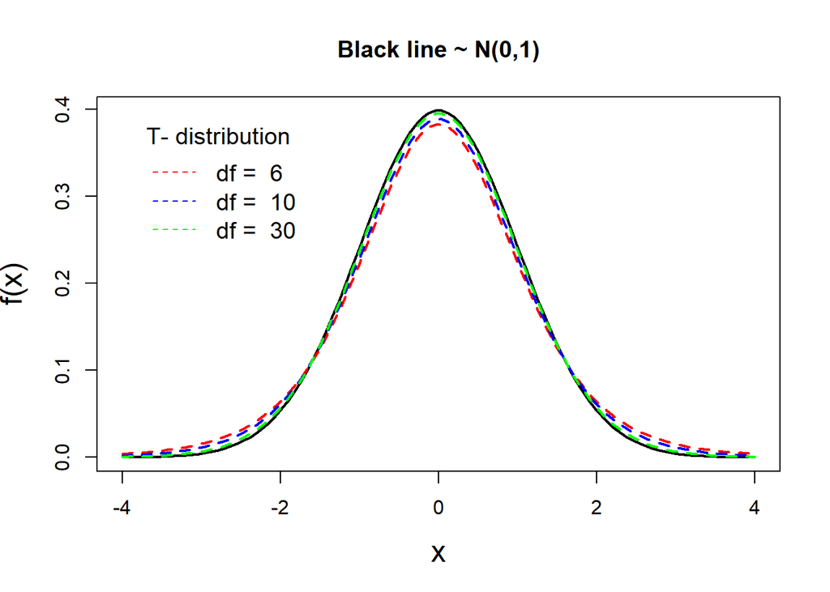

### T-분포에서 모평균의 신뢰구간

$\large \overline X - t_{(n-1, \alpha/2)}\frac{s}{\sqrt n} < \mu < \overline X + t_{(n-1, \alpha/2)}\frac{s}{\sqrt n}$

### 정규성검정: shapiro.test

```r
set.seed(7201)
df <- round(rnorm(n=10, mean = 95, sd = 16))
df
```

```
 [1]  91  94 111  85  96  91 114 101  81 100
```

```r
shapiro.test(df)
```

```
    Shapiro-Wilk normality test

data:  df
W = 1, p-value = 0.8
```

### 예제 1

```r
set.seed(7201)
df <- round(rnorm(n=10, mean = 95, sd = 16))
df
```

```
 [1]  91  94 111  85  96  91 114 101  81 100
```

```r
# mean and variance, se
df_mean <- mean(df)
est_df_se <- sd(df)/sqrt(10)

t_value <- (df_mean - 95)/est_df_se
# calculate cdf probability
pt(t_value, df = 9, lower.tail = T)
```

```
[1] 0.659
```

## T-test using r function: t.test

```r
## Default S3 method:
# t.test(x, y = NULL,
#        alternative = c("two.sided", "less", "greater"),
#        mu = 0, paired = FALSE, var.equal = FALSE,
#        conf.level = 0.95, ...)

t.test(df, alternative = "two.sided",
       mu = 95)
```

```
    One Sample t-test

data:  df
t = 0.4, df = 9, p-value = 0.7
alternative hypothesis: true mean is not equal to 95
95 percent confidence interval:
  88.9 103.9
sample estimates:
mean of x
     96.4
```

## **독립 이표본 T 검정 (Two-sample T-test)**

- 얻어진 두 랜덤표본으로부터 두 정규모집단이 같은 **평균($\mu$)** 을 가지는 지를 검증하는 통계적 방법
- 대립가설의 종류
  - $H_1:\mu_1 \neq \mu_2$, $H_0:\mu_1 = \mu_2$; (양측검정, Two-tailed)
  - $H_1:\mu_1 \gt \mu_2$, $H_0:\mu_1 \le \mu_2$; (단측검정, Upper-tailed)
  - $H_1:\mu_1 \lt \mu_2$, $H_0:\mu_1 \ge \mu_2$; (단측검정, Lower-tailed)

### 정규분포를 따르는 두 확률변수의 차의 분포

$$\large X_1 \sim N(\mu_1, \sigma_1^2),\ \ X_2 \sim N(\mu_2, \sigma_2^2)$$
$$\large X_1-X_2 \sim N(\mu_1-\mu_2, \sigma_1^2+\sigma_2^2),\ X_1 ㅛ X_2$$

### 정규분포를 따르는 두 평균의 차의 분포

$$\large \overline{X}_1-\overline{X}_2 \sim N(\mu_1-\mu_2,\ \frac{\sigma_1^2}{n_1}+\frac{\sigma_2^2}{n_2}),\ \ X_1 ㅛ X_2$$

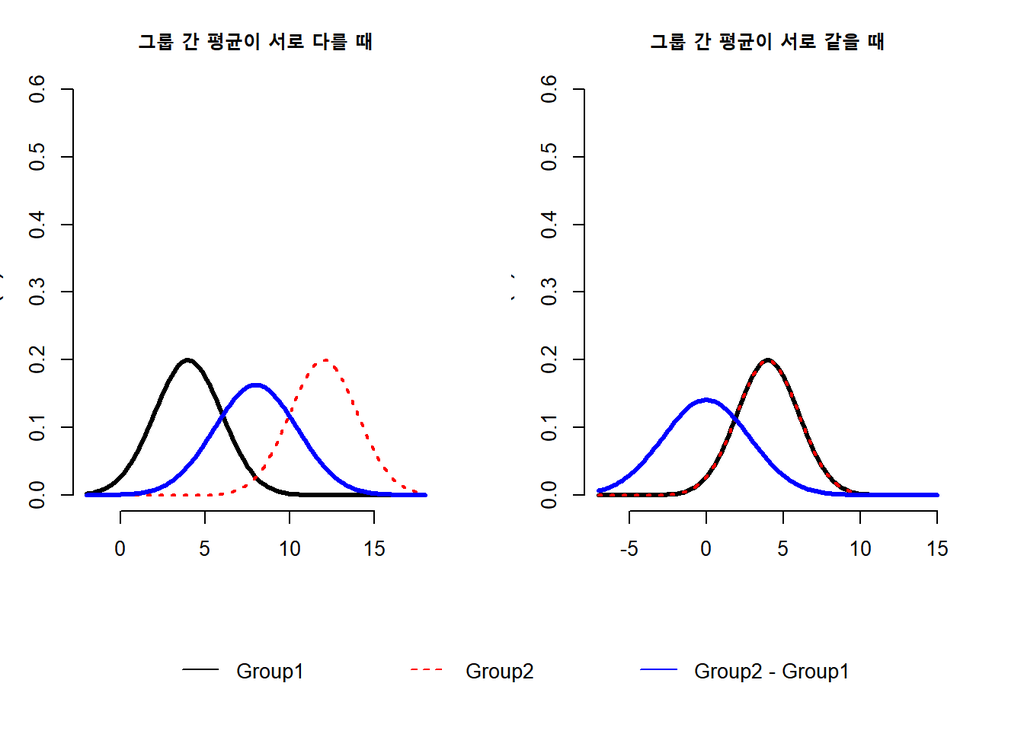

## 두 평균 차의 분포에 대한 정규화

$\large \frac{(\overline X_1 - \overline X_2) - (u_1 - u_2)}{\sqrt {(\frac{\sigma_1^2+\sigma_2^2}{n_1+n_2}})}$  
if $\sigma_1^2 = \sigma_2^2$, then $\large \frac{(\overline X_1 - \overline X_2) - (u_1 - u_2)}{\sigma^2\sqrt {(\frac{1}{n_1+n_2}})}$

## 두 모평균의 차의 신뢰구간

$\large (\overline X_1 - \overline X_2) - z_{\alpha/2}\sqrt {(\frac{\sigma_1^2+\sigma_2^2}{n_1+n_2}}) < (u_1 - u_2) < (\overline X_1 - \overline X_2) + z_{\alpha/2}\sqrt {(\frac{\sigma_1^2+\sigma_2^2}{n_1+n_2}})$

## T-분포에서 두 모평균의 차의 신뢰구간

$\large (\overline X_1 - \overline X_2) - t_{(n-2, \alpha/2)} {(\frac{\sigma_1^2+\sigma_2^2}{n_1+n_2}}) < (u_1 - u_2) < (\overline X_1 - \overline X_2) + t_{(n-2, \alpha/2)}\sqrt {(\frac{\sigma_1^2+\sigma_2^2}{n_1+n_2}})$

## 합동 표본분산 (Pooled variance)

$\large s_p^2 = \frac{(n_1-1)s_1^2 + (n_2-1)s_2^2}{n_1+n_2-2}$

### 예제

- 두 집단 간에 평균에 차이가 있는지를 검정하여라

```r
g1 <- c(1.7,3.9,1.6,4.4,2,2.2,2.6,2,0.9,0.7)
g2 <- c(1.2,3.4,2,3.6,2.5,1.4,4.7,2.9)
t.test(g1, g2, alternative = "two.sided",
       var.equal = T)
```

```
    Two Sample t-test

data:  g1 and g2
t = -0.9, df = 16, p-value = 0.4
alternative hypothesis: true difference in means is not equal to 0
95 percent confidence interval:
 -1.700  0.675
sample estimates:
mean of x mean of y
     2.20      2.71
```

### 예제

- Toothgrowth 자료를 이용하여 “len” 값의 평균이 “supp” type에 따라서 두 그룹 간에 차이가 있는지를 검정하여라

```r
t.test(len~supp, data = ToothGrowth,
       alternative = "two.sided",
       var.equal = T)
```

```
    Two Sample t-test

data:  len by supp
t = 2, df = 58, p-value = 0.06
alternative hypothesis: true difference in means is not equal to 0
95 percent confidence interval:
 -0.167  7.567
sample estimates:
mean in group OJ mean in group VC
            20.7             17.0
```

```r
# with(ToothGrowth, t.test(len ~ supp, var.equal = T))
# with(ToothGrowth, t.test(len[supp=="VC"], len[supp=="OJ"],
#                          var.equal = T))

# #subset, dose = 0.5
# with(ToothGrowth, t.test(len ~ supp, var.equal = T,
#                          subset = dose == 0.5))
# with(ToothGrowth, t.test(len[supp=="VC" & dose == 0.5],
#                          len[supp=="OJ" & dose == 0.5],
#                          var.equal = T))

# VC_len <- ToothGrowth %>%
#   filter(supp == "VC") %>%
#   pull(len)
# OJ_len <- ToothGrowth %>%
#   filter(supp == "OJ") %>%
#   pull(len)
```

## 등분산 가정 (Equality of variance, Homoscedasticity)

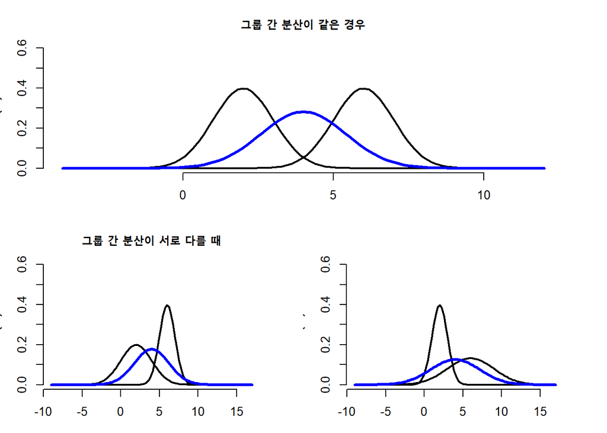

## 등분산 검정

- 임의의 k개의 표본이 동일한 분산을 가지고 있는 모집단으로 부터 얻어졌는 지를 검정
- Levene’s test
  $$\large W =\frac{N-K}{k-1}\frac{\sum_i^k N_i(Z_{i.}-Z_{..})^2}{\sum_i^k\sum_j^{N_i}(Z_{ij}-Z_{i.})^2}$$
- $Z_{ij}=|Y_{ij}-\overline{Y}_{i.}|$
- $Y_{ij}$ is the value of the measured variable for the jth case from the ith group
- Brown–Forsythe test : $\overline{Y}_{i.}$ 로서 평균대신 중앙값을 이용
- Bartlett’s test : 우드비 검정 (Likelihood ratio test, LRT)

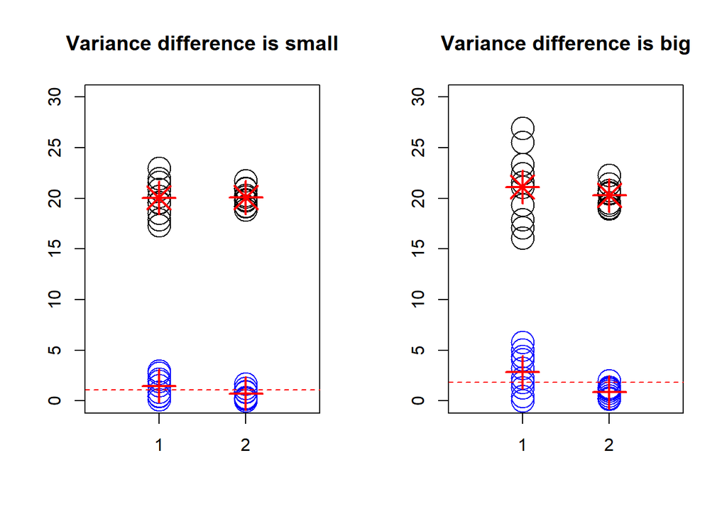

## 예제: car::levenTest

```r
library(car)
# ## S3 method for class 'formula'
# leveneTest(y, data, ...)
leveneTest(len ~ supp, data = ToothGrowth,
           center = "mean")
```

```
Levene's Test for Homogeneity of Variance (center = "mean")
      Df F value Pr(>F)
group  1     1.1    0.3
      58
```

```r
## Brown–Forsythe test
ToothGrowth %>%
  leveneTest(len ~ supp, data = ., center = "median")
```

```
Levene's Test for Homogeneity of Variance (center = "median")
      Df F value Pr(>F)
group  1    1.21   0.28
      58
```

### Welch’s T-test

- 비교하고자 하는 두 집단간 분산이 다른 경우에 사용
- 두 집단간 분산이 같은 경우 독립 두표본 T 검정과 동일한 결과를 나타냄

### 예제

```r
InsectSprays %>%
  group_by(spray) %>%
  summarise(sd = sd(count))
```

```
# A tibble: 6 x 2
  spray    sd
  <fct> <dbl>
1 A      4.72
2 B      4.27
3 C      1.98
4 D      2.50
5 E      1.73
6 F      6.21
```

```r
# spray
# <fctr>
# sd
# <dbl>
# A 4.719399
# B 4.271115
# C 1.975225
# D 2.503028
# E 1.732051
# F 6.213378
InsectSprays %>%
  filter(spray == "A" |spray == "C") %>%
  car::leveneTest(count~spray, data = .)
```

```
Levene's Test for Homogeneity of Variance (center = median)
      Df F value Pr(>F)
group  1    4.62  0.043 *
      22
---
Signif. codes:  0 '***' 0.001 '**' 0.01 '*' 0.05 '.' 0.1 ' ' 1
```

```r
with(InsectSprays, t.test(count[spray == "A"], count[spray == "C"]),
     alternative = "two.sided", var.equal = FALSE)
```

```
    Welch Two Sample t-test

data:  count[spray == "A"] and count[spray == "C"]
t = 8, df = 15, p-value = 5e-07
alternative hypothesis: true difference in means is not equal to 0
95 percent confidence interval:
  9.26 15.57
sample estimates:
mean of x mean of y
    14.50      2.08
```

## **대응표본 T 검정 (Paired T-test)**

- **서로 대응되는** 표본 측정치 간에 평균에 차이가 있는지를 검증하는 통계적 방법
- 대응 표본의 측정치 간에 서로 종속성 (dependency)이 존재
- 서로 다른 표본 간에는 독립성이 유지
- 측정치 간의 차의 자료는 정규성을 따름
- 예) 한 대상자를 일정한 시간을 두고 두 번 측정하는 경우
  - 고혈압약 투약 전과 후의 혈압
  - 교육 전후 시험의 성적
  - TV 토론 전후 지지후보에 대한 호감도
- 대립가설의 종류
  - $H_1:\mu_D \neq 0$, $H_0:\mu_D = 0$; (양측검정, Two-tailed)
  - $H_1:\mu_D \gt 0$, $H_0: \mu_D \le 0$; (단측검정, Upper-tailed)
  - $H_1:\mu_D \lt 0$, $H_0:\mu_D \ge 0$; (단측검정, Lower-tailed)

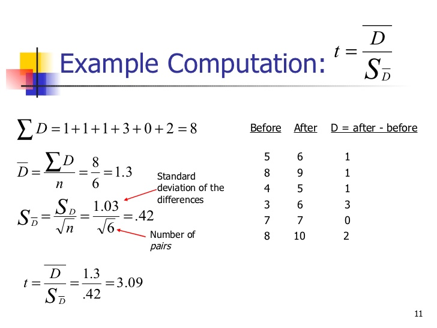

https://pt.slideshare.net/shoffma5/dependent-t-test/10

### 예제

```r
head(sleep)
```

```
  extra group ID
1   0.7     1  1
2  -1.6     1  2
3  -0.2     1  3
4  -1.2     1  4
5  -0.1     1  5
6   3.4     1  6
```

```r
shapiro <- sleep %>%
aggregate(extra ~ group, data = ., FUN = shapiro.test)

sleep %>%
  car::leveneTest(extra~group, data = .)
```

```
Levene's Test for Homogeneity of Variance (center = median)
      Df F value Pr(>F)
group  1    0.25   0.62
      18
```

```r
sleep %>%
  t.test(extra~group, data = .,
         alternative = "two.sided",
         var.equal = T,
         paired = F)
```

```
    Two Sample t-test

data:  extra by group
t = -2, df = 18, p-value = 0.08
alternative hypothesis: true difference in means is not equal to 0
95 percent confidence interval:
 -3.364  0.204
sample estimates:
mean in group 1 mean in group 2
           0.75            2.33
```

```r
sleep %>%
  t.test(extra~group, data = .,
         alternative = "two.sided",
         paired = T)
```

```
    Paired t-test

data:  extra by group
t = -4, df = 9, p-value = 0.003
alternative hypothesis: true difference in means is not equal to 0
95 percent confidence interval:
 -2.46 -0.70
sample estimates:
mean of the differences
                  -1.58
```

### Two-sample T-test samples

- Airquality
- Warpbreaks (http://www.jerrydallal.com/LHSP/ci_logs.htm)
- ChickenWeight

# **일원배치 분산분석 (One-way ANOVA; Analysis of variance)**

- 요인 (factor)가 하나이고 수준수(Level or treatment)가 3개 이상인 경우에 수준간 자료가 평균이 서로 다른 모집단으로 부터 생성되었는지를 검증하는 통계적 방법
- 분산분석의 가정: $X_{ij} \sim^{i.i.d} N(\mu_i, \sigma^2), \ \forall i,j$
- 독립성 (Independency), 정규성 (Normality), 등분산성 (Homoscedasticity)
- 가설  
  $H_0: \mu_1 = \mu_2 = ... = \mu_k$  
  $H_1:$, 그룹간 평균의 차이가 있다.
  - $\mu_1 \neq \mu_2 = ... = \mu_k$
  - $\mu_1 = \mu_2 \neq ... = \mu_k$
  - $\mu_1 = \mu_2 = ... \neq \mu_k$
  - $\mu_1 \neq \mu_2 \neq ... = \mu_k$
  - …
  - $\mu_1 \neq \mu_2 \neq ... \neq \mu_k$

## ANOVA 구조모형

$$\large Y_{ij} = \mu + \alpha_i + \epsilon_{ij},$$
$$\large \epsilon_{ij} \sim^{i.i.d} N(0, \sigma^2), \ \forall i,j$$
$$\large i = 1, 2, ...,k; \ \ j = 1, 2, ..., N_i$$
$\mu: 전체 \ 모평균$
$\alpha_i: Treatment\ 에\ 의한\ 효과, \sum \alpha_i = 0$

## 총변동의 분할

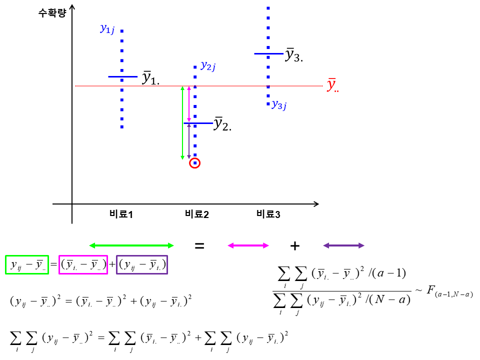

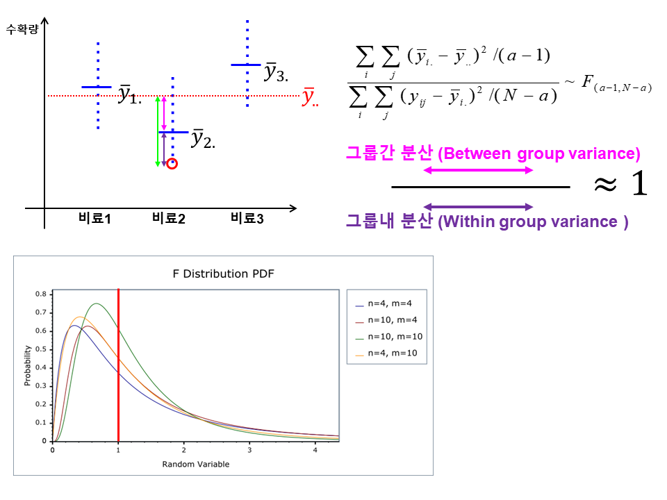

## 분산분석표의 작성(ANOVA Table)

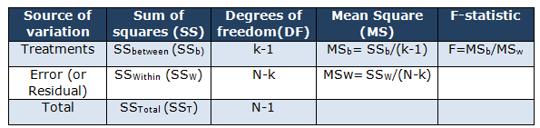

https://sixsigmastudyguide.com/anova-analysis-of-variation

## 예제

```
# A tibble: 3 x 3
      A     B     C
  <dbl> <dbl> <dbl>
1     2     4     6
2     4     6     8
3     6     8    10
```

### ANOVA using General linear model

```r
df_long <- anova.example %>%
  pivot_longer(everything())

# df_long %>%
#   group_by(name) %>%
#   summarize(mean = mean(value))

lmfit.result <- lm(value~name, data = df_long)
summary(lmfit.result)
```

```
Call:
lm(formula = value ~ name, data = df_long)

Residuals:
   Min     1Q Median     3Q    Max
    -2     -2      0      2      2

Coefficients:
            Estimate Std. Error t value Pr(>|t|)
(Intercept)     4.00       1.15    3.46    0.013 *
nameB           2.00       1.63    1.22    0.267
nameC           4.00       1.63    2.45    0.050 *
---
Signif. codes:  0 '***' 0.001 '**' 0.01 '*' 0.05 '.' 0.1 ' ' 1

Residual standard error: 2 on 6 degrees of freedom
Multiple R-squared:   0.5,  Adjusted R-squared:  0.333
F-statistic:    3 on 2 and 6 DF,  p-value: 0.125
```

### 예제, Chickwt 자료를 이용하여 사료 종류에 따라 닭의 성장속도에 통계적으로 유의한 차이가 있는지를 판단하여라

```r
# solving least square using QR factorization
# http://www.seas.ucla.edu/~vandenbe/133A/lectures/ls.pdf

# stats::lm(formula, data, subset, weights, na.action,
#    method = "qr", model = TRUE, x = FALSE, y = FALSE, qr = TRUE,
#    singular.ok = TRUE, contrasts = NULL, offset, ...)

## GLM method
lm.result <- lm(weight ~ feed, data = chickwts)

# anova table for fitted model object
anova(lm.result)
```

```
Analysis of Variance Table

Response: weight
          Df Sum Sq Mean Sq F value  Pr(>F)
feed       5 231129   46226    15.4 5.9e-10 ***
Residuals 65 195556    3009
---
Signif. codes:  0 '***' 0.001 '**' 0.01 '*' 0.05 '.' 0.1 ' ' 1
```

```r
# aov(lm.result)
# estimate parameter

summary(lm.result)
```

```
Call:
lm(formula = weight ~ feed, data = chickwts)

Residuals:
    Min      1Q  Median      3Q     Max
-123.91  -34.41    1.57   38.17  103.09

Coefficients:
              Estimate Std. Error t value Pr(>|t|)
(Intercept)     323.58      15.83   20.44  < 2e-16 ***
feedhorsebean  -163.38      23.49   -6.96  2.1e-09 ***
feedlinseed    -104.83      22.39   -4.68  1.5e-05 ***
feedmeatmeal    -46.67      22.90   -2.04  0.04557 *
feedsoybean     -77.15      21.58   -3.58  0.00067 ***
feedsunflower     5.33      22.39    0.24  0.81249
---
Signif. codes:  0 '***' 0.001 '**' 0.01 '*' 0.05 '.' 0.1 ' ' 1

Residual standard error: 54.9 on 65 degrees of freedom
Multiple R-squared:  0.542, Adjusted R-squared:  0.506
F-statistic: 15.4 on 5 and 65 DF,  p-value: 5.94e-10
```

```r
## aov method
aov.result <- stats::aov(weight ~ feed, data = chickwts)
# summary(aov.result)
```

### 사후검정 (post-hoc test)

```r
stats::TukeyHSD(aov.result)
```

```
  Tukey multiple comparisons of means
    95% family-wise confidence level

Fit: stats::aov(formula = weight ~ feed, data = chickwts)

$feed
                       diff     lwr   upr p adj
horsebean-casein    -163.38 -232.35 -94.4 0.000
linseed-casein      -104.83 -170.59 -39.1 0.000
meatmeal-casein      -46.67 -113.91  20.6 0.332
soybean-casein       -77.15 -140.52 -13.8 0.008
sunflower-casein       5.33  -60.42  71.1 1.000
linseed-horsebean     58.55  -10.41 127.5 0.141
meatmeal-horsebean   116.71   46.34 187.1 0.000
soybean-horsebean     86.23   19.54 152.9 0.004
sunflower-horsebean  168.72   99.75 237.7 0.000
meatmeal-linseed      58.16   -9.07 125.4 0.128
soybean-linseed       27.68  -35.68  91.0 0.793
sunflower-linseed    110.17   44.41 175.9 0.000
soybean-meatmeal     -30.48  -95.38  34.4 0.739
sunflower-meatmeal    52.01  -15.22 119.2 0.221
sunflower-soybean     82.49   19.13 145.9 0.004
```

```r
# pairwise.t.test(x, g, p.adjust.method = p.adjust.methods,
#                 pool.sd = !paired, paired = FALSE,
#                 alternative = c("two.sided", "less", "greater"),
#                 ...)

# p.adjust.methods
# c("holm", "hochberg", "hommel", "bonferroni", "BH", "BY",
#   "fdr", "none")

chickwts %$%
pairwise.t.test(x = weight, g = feed,
                p.adjust.method = "holm")
```

```
    Pairwise comparisons using t tests with pooled SD

data:  weight and feed

          casein horsebean linseed meatmeal soybean
horsebean 3e-08  -         -       -        -
linseed   2e-04  0.094     -       -        -
meatmeal  0.182  9e-05     0.094   -        -
soybean   0.005  0.003     0.518   0.518    -
sunflower 0.812  1e-08     8e-05   0.132    0.003

P value adjustment method: holm
```

### 예제, Toothgrowth 자료를 이용하여 vitamine 투여량과 투여방법에 따라 guinea pigs 상아질모세포 (odontoblasts)의 성장속도에 통계적으로 유의한 차이가 있는지를 판단하여라

```r
ToothGrowth <- ToothGrowth %>%
  mutate(dose = factor(dose))

set.seed(72)
ToothGrowth_df <- ToothGrowth %>%
  # group_by(dose, supp) %>%
  sample_frac(0.7)
# with(ToothGrowth, stats::interaction.plot(dose, supp, len, fun = mean,
#                              main = "Interaction Plot"))

lm2.result <- lm(len ~ supp * dose, data = ToothGrowth_df)
anova(lm2.result)
```

```
Analysis of Variance Table

Response: len
          Df Sum Sq Mean Sq F value  Pr(>F)
supp       1     64      64    6.60   0.015 *
dose       2   1856     928   95.88 3.8e-15 ***
supp:dose  2     97      48    5.01   0.012 *
Residuals 36    348      10
---
Signif. codes:  0 '***' 0.001 '**' 0.01 '*' 0.05 '.' 0.1 ' ' 1
```

```r
summary(lm2.result)
```

```
Call:
lm(formula = len ~ supp * dose, data = ToothGrowth_df)

Residuals:
   Min     1Q Median     3Q    Max
-8.156 -2.182 -0.011  2.350  7.244

Coefficients:
             Estimate Std. Error t value Pr(>|t|)
(Intercept)     12.30       1.27    9.68  1.5e-11 ***
suppVC          -3.50       1.68   -2.08    0.044 *
dose1           10.38       1.80    5.78  1.4e-06 ***
dose2           13.27       1.80    7.39  1.0e-08 ***
suppVC:dose1    -2.85       2.41   -1.18    0.244
suppVC:dose2     4.59       2.35    1.95    0.058 .
---
Signif. codes:  0 '***' 0.001 '**' 0.01 '*' 0.05 '.' 0.1 ' ' 1

Residual standard error: 3.11 on 36 degrees of freedom
Multiple R-squared:  0.853, Adjusted R-squared:  0.832
F-statistic: 41.7 on 5 and 36 DF,  p-value: 5.41e-14
```

```r
# aov2.result <- aov(len ~ supp * dose, data = ToothGrowth)
# summary(aov2.result)
```

### Interaction plot

```r
with(ToothGrowth, interaction.plot(dose, supp, len, fun = mean,
                             main = "Interaction Plot"))
```

[output not shown]

### post-hoc

```r
aov2.result <- aov(len ~ supp * dose, data = ToothGrowth)
summary(aov2.result)
```

```
            Df Sum Sq Mean Sq F value  Pr(>F)
supp         1    205     205   15.57 0.00023 ***
dose         2   2426    1213   92.00 < 2e-16 ***
supp:dose    2    108      54    4.11 0.02186 *
Residuals   54    712      13
---
Signif. codes:  0 '***' 0.001 '**' 0.01 '*' 0.05 '.' 0.1 ' ' 1
```

```r
TukeyHSD(aov2.result)
```

```
  Tukey multiple comparisons of means
    95% family-wise confidence level

Fit: aov(formula = len ~ supp * dose, data = ToothGrowth)

$supp
      diff   lwr   upr p adj
VC-OJ -3.7 -5.58 -1.82     0

$dose
       diff   lwr   upr p adj
1-0.5  9.13  6.36 11.90     0
2-0.5 15.50 12.73 18.26     0
2-1    6.37  3.60  9.13     0

$`supp:dose`
               diff    lwr    upr p adj
VC:0.5-OJ:0.5 -5.25 -10.05 -0.452 0.024
OJ:1-OJ:0.5    9.47   4.67 14.268 0.000
VC:1-OJ:0.5    3.54  -1.26  8.338 0.264
OJ:2-OJ:0.5   12.83   8.03 17.628 0.000
VC:2-OJ:0.5   12.91   8.11 17.708 0.000
OJ:1-VC:0.5   14.72   9.92 19.518 0.000
VC:1-VC:0.5    8.79   3.99 13.588 0.000
OJ:2-VC:0.5   18.08  13.28 22.878 0.000
VC:2-VC:0.5   18.16  13.36 22.958 0.000
VC:1-OJ:1     -5.93 -10.73 -1.132 0.007
OJ:2-OJ:1      3.36  -1.44  8.158 0.319
VC:2-OJ:1      3.44  -1.36  8.238 0.294
OJ:2-VC:1      9.29   4.49 14.088 0.000
VC:2-VC:1      9.37   4.57 14.168 0.000
VC:2-OJ:2      0.08  -4.72  4.878 1.000
```

## 평균제곱의 기대값

$$\large E(MS_b) = \sigma_E^2 \ +\ \sum_i^k\frac{\alpha_i^2}{k-1}$$
$$\large E(MS_w) = \sigma_E^2$$

## 분산분석 후에 추정

$$\large E(\overline{x}_{i.}) = \mu + \alpha_i = \mu_i$$
$$Var(\overline{x}_{i.}) = \frac{\sigma_E^2}{r}$$
$$\overline{x}_{i.} \sim N(\mu_i, \frac{\sigma_E^2}{r})$$
$$\large E(MS_w) = \sigma_E^2$$
$$\overline{x}_{i.} \pm t(\phi_i;\frac{\alpha}{2})\sqrt{\frac{MS_w}{r}}$$
$$\overline{x}_{i.} -\overline{x}_{j.} \pm t(\phi_i;\frac{\alpha}{2})\sqrt{\frac{2MS_w}{r}}$$

## Effect size

$$\large \eta^2 = \frac{SS_B}{SS_T}$$
$$\large \eta_p^2 = \frac{SS_{treatment}}{SS_{treatment} + SS_W}$$
$$\large \omega^2 = \frac{SS_{treatment}-df_{treatment}*MS_{error}}{SS_{Total} + MS_{error}}$$

## Post-hoc test

### Multiple comparison problem

- Family wise type 1 error rate (FWER)

$$FWER = P\{{\cup_{i=1}^{n}(p_i \le \alpha)\}} = 1 - P(1-\alpha)^n \le n\alpha$$
$p_i$ = Individual P-value
$\alpha$ = Type 1 error
$n$ = Number of comparison

### FWER correction

- Bonferroni: Set $\alpha_c = \frac{\alpha}{n}$
- Holm–Bonferroni method : Bonferroni 보다 검정력이 좋음
  - ordering p-value $P_{(1)}...P_{(n)}\ and\ H_{(1)}...H_{(n)}$
  - Set minimal index k $P_{(k)} > \frac{\alpha}{n+1-k}$
  - Reject the null hypothesis $\ H_{(1)}...H_{(k-1)}$
- Tukey: **각 수준당 표본의 갯수가 동일**
  - $HSD = q \sqrt\frac{MS_w}{n_k}$
  - $q$ = Studentized range (from Table)
  - $MS_w$ = Mean square within
  - $n_k$ = Number in each level
- Sheffe: $\sqrt{(k-1)F(k-1, N-r)}$

# **이원배치 분산분석 (Two-way ANOVA)**

$$\large Y_{ijk} = \mu + \alpha_i + \beta_j + \alpha\beta_{ij}+\epsilon_{ijk},$$
$$\large \epsilon_{ijk} \sim^{i.i.d} N(0, \sigma^2), \ \forall i,j, k$$
$$\large i = 1, 2, ...,l; \ \ j = 1, 2, ..., m; \\k = 1,...,n$$

$\mu: 전체 \ 모평균$  
$\alpha_i: 요인 A\ Treatment\ 에\ 의한\ 효과, \sum \alpha_i = 0$  
$\beta_j: 요인 B \ Treatment\ 에\ 의한\ 효과, \sum \beta_j = 0$  
$\alpha\beta_{ij}$: 요인 A와 B의 상호작용 효과, $\sum \alpha\beta_{ij} = 0$

## Interaction effect

- 상호작용 효과란 각 요인들의 결합효과로서 종속변수에 대한 각 요인들의 효과가 각 수준들 간에서 서로 다르게 나타나는 효과

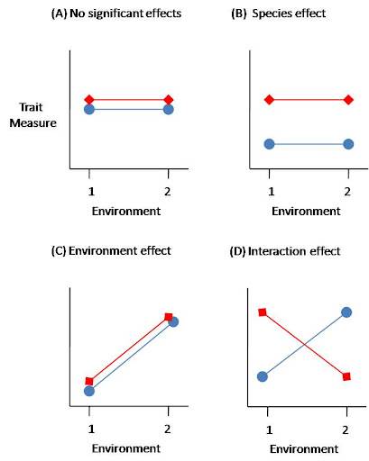

https://skeetersays.wordpress.com/2008/08/12/demystifying-statistics-on-the-interpretation-of-anova-effects

### Estimated marginal mean

- pigs data

# **회귀분석 (Linear regresion)**

- 변수간에 선형적 `인과관계`가 있는 지를 분석하는 통계적 방법
- 반응변수가 연속형인 경우에 사용
- 설명변수는 연속형과 범주형 모두 가능

## 회귀분석 (linear regression) 의 구조 모형

### 단순선형회귀모형

$$Y_i = \beta_0 + \beta_1X_{1i} + \epsilon_{i}$$

### 다중선형회귀모형

$$Y_i = \beta_0 + \beta_1X_{1i} + \beta_2X_{2i} + \dots + \beta_KX_{Ki} + \epsilon_{i}$$

### 선형회귀모형의 분포가정

- $\epsilon_{i} \sim^{i.i.d} N(\beta^TX, \sigma^2), \ \forall i$  
  where, $\small \beta^TX = \beta_0 + \beta_1X_{1i} + \beta_2X_{2i} + \ ...\ \beta_KX_{Ki}$
- 독립성 (Independency), 정규성 (Normality), 등분산성 (Homoscedasticity)

### 예

| 혈압 | 나이 | 콜레스테롤 |
| --- | --- | --- |
| 140 | 73 | 66 |
| 146 | 65 | 73 |
| 176 | 70 | 88 |
| 162 | 62 | 74 |
| 132 | 68 | 64 |